# Chapter 5

The impact of elective care on emergency care

Steven Wyatt, The Strategy Unit

16 March 2021

### 1 Introduction

In the previous chapters we have explored inequalities and inequities in access to planned secondary care. In this chapter we examine the consequences of this inequity on the patients use of emergency care. The analysis contrasts socio-economic gradients in planned care and unplanned care, changes in rates of these types of care over time and the rates of emergency care in the months prior to and after an elective spell. Finally we test the extent to inequities in access to elective care can explain elevated rates of emergency care in the most deprived populations.

### 2 Set-up

##### 2.1 Load required R packages

Set working directory.

Packages: tidyverse, scales, broom and plm

```r
setwd('Z:/Strategic Analytics/Projects 2020/753 Ineq Planned Care/panelAnalysis/r - IneqPlannedCare/r - IneqPlannedCare')

library(tidyverse)
library(scales)
library(broom)
library(plm)
library(ggrepel)
```

##### 2.1 Read in data sets

The first file contain activity rates, both crude and directly age-sex standardised and population by: - year (2005 to 2018) - activity type (elective spells, emergency spells and outpatient attendances) - STP/ICS - deprivation decile (IMD2019) - ICD10 chapter of the primary diagnosis (elective spells, emergency spells only)

File two contains counts of activity by: - year (2005 to 2018) - activity type (elective spells, emergency spells) - ICD10 chapter of the primary diagnosis

File three is panel data, with year as the time variable and CCG as the cross-sectional variable. The dataset includes the following variables; - year (2002 to 2018) - CCG (135 CCGs as at 2020) - total population (derived from ONS mid-year estimates) - female population - population aged 65 and over - population aged 75 and over - population aged 85 and over - population aged 19 and less - mean deprivation score (IMD2019) of the LSOAs within the CCG - deaths - elective spells (all, day case and ordinary) - emergency spells - other inpatient spells (maternity, other, unknown) - outpatient attendances (first, follow-up, face-to-face, telephone, other)

The fourth file contains a record for each elective admission in April2017 - March 2018 in England with valid age and sex, (index spells). In addition the file contains information about emergency admissions within 365 days (if any) of an index spell, (prox spells). Note that if more than ‘prox spell’ then the the index spell will be duplicated. For each index spell the file also contains a count count of emergency admissions in 2016/17 (priorEmAdms).

the fifth file contains a count of patients by age, sex, emergency admissions in 2016/17 and 2017/18. counts of emergency admissions greater than or equal to 5 are grouped. Note that this table will not include patients with no emergency admissions in either 2016/17 or 2017/18.

The sixth file contains the England mid -year population estimates in 2017 by age and sex, published by ONS.

The last file is a look-up from CCG to STP/ICS in 2020 taken from the ONMS geography portal.

```r
actRates <- readRDS(file = 'actRates.RDS')

ipActIcd10Yr <- readRDS(file = 'ipActIcd10Yr.RDS')

IneqSecCarePanel <- readRDS(file = 'IneqSecCarePanel.RDS')

IneqSecCareReadm_IndexProxPriorSpells <- readRDS(file = 'IneqSecCareReadm_IndexProxPriorSpells.RDS')

IneqSecCareReadm_EmAdm1617_1718_Grp <- readRDS(file = 'IneqSecCareReadm_EmAdm1617_1718_Grp.RDS')

IneqSecCareReadmPop <- readRDS(file = 'IneqSecCareReadmPop.RDS')

ccgStp  <- read.csv(file = 'Clinical_Commissioning_Group_to_STPs_(April_2020)_Lookup_in_England.csv') %>%
  dplyr::select(CCG20CD, STP20CD)
```

### 3 Exploratory analysis

##### 3.1 rates of elective of emergency spells by deprivation

In this section we explore how rates of elective of emergency spells by vary by deprivation decile.

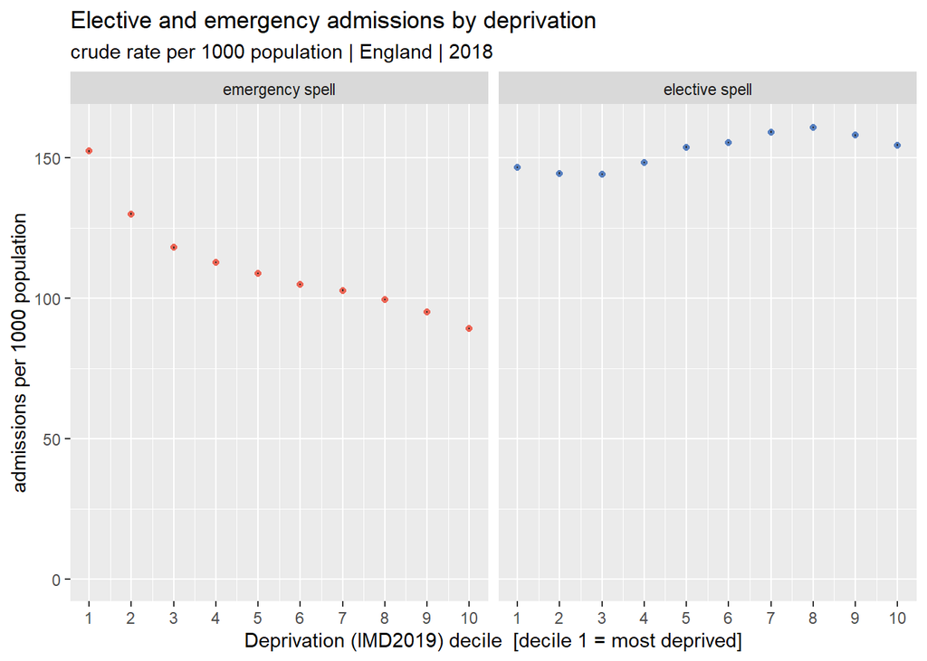

```r
actRates %>%
  filter(actType == 'ipElec' | actType == 'ipEmer') %>%
  filter(rateType == 'crude') %>%
  filter(STP20CD == 'all') %>%
  filter(imd2019Dec != 'all') %>%
  filter(icd10Chapter == 'all') %>%
  filter(yr == 2018) %>%
  ggplot() +
  geom_point(aes(x = as.numeric(imd2019Dec), y = rate*1000, colour = actTypeLabel)) +
  geom_segment(aes(x = as.numeric(imd2019Dec), xend = as.numeric(imd2019Dec), y = lcl95*1000, yend = ucl95*1000),
               colour = '#2c2825') +
  scale_color_manual(values = c('#ec6555', '#5881c1')) +
  scale_y_continuous(name = 'admissions per 1000 population',
                     limits = c(0, NA_real_)) +
  scale_x_continuous(name = 'Deprivation (IMD2019) decile  [decile 1 = most deprived]', breaks = seq(1, 10, 1)) +
  labs(title = 'Elective and emergency admissions by deprivation',
       subtitle = 'crude rate per 1000 population | England | 2018') +
  facet_wrap(~actTypeLabel) +
  theme(legend.position = 'none')
```

In Chapter 2 we saw that rates of elective spells were lower in the most deprived areas. Here we show that the opposite is the case for emergency spells: rates are higher for those living in the most deprived areas.

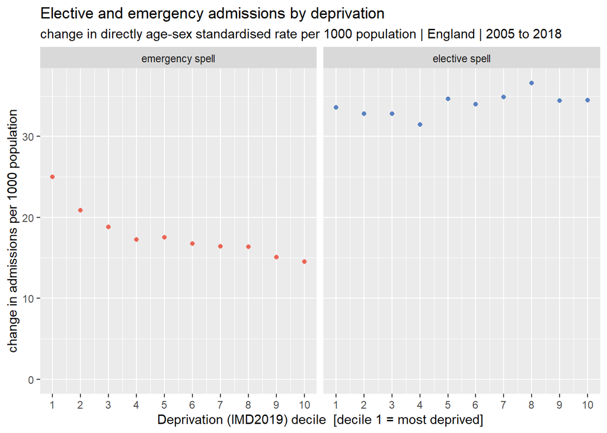

```r
actRates %>%
  filter(actType == 'ipElec' | actType == 'ipEmer') %>%
  filter(rateType == 'dsr') %>%
  filter(STP20CD == 'all') %>%
  filter(imd2019Dec != 'all') %>%
  filter(icd10Chapter == 'all') %>%
  filter(yr == 2018 | yr == 2005) %>%
  select(yr, imd2019Dec, actType, actTypeLabel, rateType, rate) %>%
  pivot_wider(names_from = yr, values_from = rate, names_prefix = 'rate') %>%
  mutate(absDiffRate = rate2018 - rate2005,
         relDiffRate = (rate2018 - rate2005) / rate2005) %>%
  ggplot() +
  geom_point(aes(x = as.numeric(imd2019Dec), y = absDiffRate*1000, colour = actTypeLabel)) +
  scale_y_continuous(name = 'change in admissions per 1000 population',
                     limits = c(0, NA_real_)) +
  scale_x_continuous(name = 'Deprivation (IMD2019) decile  [decile 1 = most deprived]', breaks = seq(1, 10, 1)) +
  scale_color_manual(values = c('#ec6555', '#5881c1')) +
  labs(title = 'Elective and emergency admissions by deprivation',
       subtitle = 'change in directly age-sex standardised rate per 1000 population | England | 2005 to 2018') +
  facet_wrap(~actTypeLabel) +
  theme(legend.position = 'none')
```

After adjusting for changes in the population structure, we can see there have been greater increases in the rates of elective spells in the least deprived areas, while the greatest growth in rates of emergency spells has taken place among populations living in the most deprived areas.

In this section we explore how rates of elective of emergency spells by vary by deprivation decile within each ICD10 chapter.

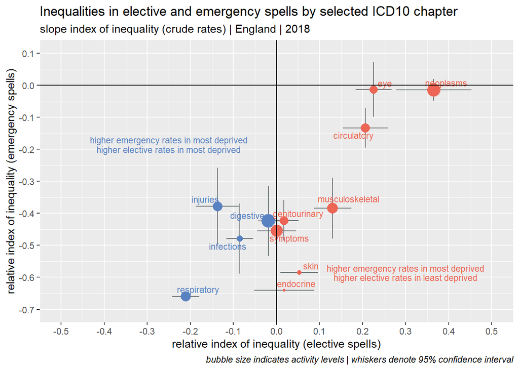

```r
# calculate slope index of inequality by deprivation, activity type and icd10 chapter
siiIcd10ResultsDf <- data.frame(icd10Chapter = character(),
                                actType = character(),
                                rateType = character(),
                                pred1 = numeric(),
                                pred1se = numeric(),
                                pred10 = numeric(),
                                pred10se = numeric())



for (j in c('CD04', 'K', 'M', 'J', 'N', 'ST', 'R', 'H05', 'I', 'L', 'E', 'AB'))
{

  for (k in c('ipEmer', 'ipElec'))

  {

    modDf <- actRates %>%
      filter(rateType == 'crude') %>%
      filter(actType == k) %>%
      filter(icd10Chapter == j) %>%
      filter(imd2019Dec != 'all') %>%
      filter(yr == 2018) %>%
      mutate(imd2019Dec = as.numeric(imd2019Dec))

    mod <- lm(rate ~ imd2019Dec,
              data = modDf,
              weights = pop)

    modResults <- data.frame(icd10Chapter = j,
                             rateType = 'crude',
                             actType = k,
                             pred1 = predict(mod)[1],
                             pred1se = predict(mod, se.fit = TRUE)$se.fit[1],
                             pred10 = predict(mod)[10],
                             pred10se = predict(mod, se.fit = TRUE)$se.fit[10])

    siiIcd10ResultsDf <- siiIcd10ResultsDf %>%
      bind_rows(modResults)

  }

}


# calculate se and confidence intervals of sii

siiIcd10ResultsDf <- siiIcd10ResultsDf %>%
  mutate(sii = pred10 - pred1) %>%
  mutate(siiSe = (pred1se ^ 2  + pred10se ^ 2) ^ 0.5) %>%
  mutate(siiLcl95 = sii - 1.96*siiSe,
         siiUcl95 = sii + 1.96*siiSe)



riiIcd10ResultsDf <- siiIcd10ResultsDf %>%
  left_join(ipActIcd10Yr %>%
              filter(yr == 2018) %>%
              ungroup() %>%
              select(icd10Chapter, actType, act),
            by = c('icd10Chapter', 'actType')) %>%
  mutate(icd10Label = case_when(icd10Chapter == 'AB' ~ 'infections',
                                icd10Chapter == 'CD04' ~ 'neoplasms',
                                icd10Chapter == 'D59' ~ 'blood',
                                icd10Chapter == 'E' ~ 'endocrine',
                                icd10Chapter == 'F' ~ 'mental health',
                                icd10Chapter == 'G' ~ 'nervous system',
                                icd10Chapter == 'H05' ~ 'eye',
                                icd10Chapter == 'H69' ~ 'ear',
                                icd10Chapter == 'I' ~ 'circulatory',
                                icd10Chapter == 'J' ~ 'respiratory',
                                icd10Chapter == 'K' ~ 'digestive',
                                icd10Chapter == 'L' ~ 'skin',
                                icd10Chapter == 'M' ~ 'musculoskeletal',
                                icd10Chapter == 'N' ~ 'genitourinary',
                                icd10Chapter == 'O' ~ 'pregnancy',
                                icd10Chapter == 'P' ~ 'perinatal',
                                icd10Chapter == 'Q' ~ 'congenital',
                                icd10Chapter == 'R' ~ 'symptoms',
                                icd10Chapter == 'ST' ~ 'injuries',
                                icd10Chapter == 'VWXY' ~ 'external causes',
                                icd10Chapter == 'Z' ~ 'other factors',
                                icd10Chapter == 'U' ~ 'unknown',
                                TRUE ~ 'check')) %>%
  mutate(actTypeLabel = ifelse(actType == 'ipEmer', 'emergency spells', 'elective spells')) %>%
  left_join(actRates %>%
              filter(yr == 2018) %>%
              filter(actType == 'ipElec' | actType == 'ipEmer') %>%
              filter(rateType == 'crude') %>%
              filter(icd10Chapter != 'all') %>%
              filter(imd2019Dec == 'all') %>%
              filter(STP20CD == 'all') %>%
              mutate(icd10Label = case_when(icd10Chapter == 'AB' ~ 'infections',
                                            icd10Chapter == 'CD04' ~ 'neoplasms',
                                            icd10Chapter == 'D59' ~ 'blood',
                                            icd10Chapter == 'E' ~ 'endocrine',
                                            icd10Chapter == 'F' ~ 'mental health',
                                            icd10Chapter == 'G' ~ 'nervous system',
                                            icd10Chapter == 'H05' ~ 'eye',
                                            icd10Chapter == 'H69' ~ 'ear',
                                            icd10Chapter == 'I' ~ 'circulatory',
                                            icd10Chapter == 'J' ~ 'respiratory',
                                            icd10Chapter == 'K' ~ 'digestive',
                                            icd10Chapter == 'L' ~ 'skin',
                                            icd10Chapter == 'M' ~ 'musculoskeletal',
                                            icd10Chapter == 'N' ~ 'genitourinary',
                                            icd10Chapter == 'O' ~ 'pregnancy',
                                            icd10Chapter == 'P' ~ 'perinatal',
                                            icd10Chapter == 'Q' ~ 'congenital',
                                            icd10Chapter == 'R' ~ 'symptoms',
                                            icd10Chapter == 'ST' ~ 'injuries',
                                            icd10Chapter == 'VWXY' ~ 'external causes',
                                            icd10Chapter == 'Z' ~ 'other factors',
                                            icd10Chapter == 'U' ~ 'unknown',
                                            TRUE ~ 'check')) %>%
              select(icd10Label, actType, globalRate = rate),
            by = c('icd10Label', 'actType'))  %>%
  mutate(rii = sii / globalRate) %>%
  mutate(riiLcl95 = siiLcl95 / globalRate,
         riiUcl95 = siiUcl95 / globalRate)



riiIcd10ResultsDf %>%
  select(icd10Chapter, icd10Label, actType, rii, riiLcl95, riiUcl95) %>%
  pivot_longer(cols = 4:6,
               names_to = 'metric',
               values_to = 'value') %>%
  pivot_wider(names_from = actType,
              values_from = value) %>%
  pivot_wider(names_from = 'metric',
              values_from = c(ipEmer, ipElec)) %>%
  left_join(riiIcd10ResultsDf %>%
              group_by(icd10Chapter, icd10Label) %>%
              summarise(act = sum(act)),
            by = c('icd10Chapter', 'icd10Label')) %>%
  mutate(quadrant = case_when(ipElec_rii > 0  & ipEmer_rii > 0  ~ 'tr',
                              ipElec_rii > 0  & ipEmer_rii <= 0 ~ 'br',
                              ipElec_rii <= 0 & ipEmer_rii > 0  ~ 'tl',
                              TRUE ~ 'bl')) %>%
  ggplot() +
  geom_segment(aes(x = ipElec_rii,
                   xend = ipElec_rii,
                   y = ipEmer_riiLcl95,
                   yend = ipEmer_riiUcl95), colour = '#686f73') +
  geom_segment(aes(x = ipElec_riiLcl95,
                   xend = ipElec_riiUcl95,
                   y = ipEmer_rii,
                   yend = ipEmer_rii), colour = '#686f73') +
  geom_point(aes(x = ipElec_rii, ipEmer_rii, size = act, colour = quadrant)) +
  geom_text_repel(aes(x = ipElec_rii, ipEmer_rii, label = icd10Label, colour = quadrant),
             segment.alpha = 0,
            size = 3) +
  geom_hline(aes(yintercept = 0)) +
  geom_vline(aes(xintercept = 0)) +
  annotate('text', x = -0.25, y = -0.2, label = 'higher elective rates in most deprived', colour = '#5881c1', size = 3) +
  annotate('text', x = -0.25, y = -0.17, label = 'higher emergency rates in most deprived', colour = '#5881c1', size = 3) +
  annotate('text', x = 0.3, y = -0.6, label = 'higher elective rates in least deprived', colour = '#ec6555', size = 3) +
  annotate('text', x = 0.3, y = -0.57, label = 'higher emergency rates in most deprived', colour = '#ec6555', size = 3) +
  #
  scale_x_continuous(name = 'relative index of inequality (elective spells)',
                limits = c(-0.5, 0.5),
                breaks= seq(-0.5, 0.5, 0.1)) +
  scale_y_continuous(name = 'relative index of inequality (emergency spells)',
                limits = c(-0.7, 0.1),
                breaks = c(-0.7, -0.6, -0.5, -0.4, -0.3, -0.2, -0.1, 0, 0.1)) +
  scale_colour_manual(values = c('#5881c1', '#ec6555', '#f9bf07', '#686f73')) +
  labs(title = 'Inequalities in elective and emergency spells by selected ICD10 chapter',
       subtitle = 'slope index of inequality (crude rates) | England | 2018',
       caption = 'bubble size indicates activity levels | whiskers denote 95% confidence interval') +
  theme(legend.position = 'none',
        plot.caption = element_text(face = 'italic'))
```

These patterns appear to hold for many of the major ICD10 chapters - higher elective spell rates in the least deprived areas and higher emergency spell rates in the most deprived areas.

##### 3.3 Rates of emergency spells prior to and after an elective spell

In the section we explore the rates of emergency admissions that patients experience in the weeks and months leading up to and after an elective spell.

###### 3.3.1 Wrangle data

Count actual emergency spells for index spells by week from one year prior to admission for the index elective spell, to one year after discharge from the index spell.

Calculate the background risk of an emergency admission by age and sex. Assign these to index spells as the counterfactual rates of emergency spells

Aggregate results in the 42 days prior to index spell admission and 42 after index spell discharge by deprivation quintile, STP, ICD10 Chapter.

```r
# start by working out non-admitted pop by age and sex
noEmAdmsPats <- IneqSecCareReadm_EmAdm1617_1718_Grp %>%
  rename(sex = gender) %>%
  mutate(sex = as.numeric(sex)) %>%
  group_by(age, sex) %>%
  summarise(pats = sum(pats)) %>%
  left_join(IneqSecCareReadmPop, by = c('age', 'sex')) %>%
  mutate(noEmAdmPats = pop - pats) %>%
  mutate(emAdms1617 = 0,
         emAdms1718 = 0) %>%
  select(age, sex, emAdms1617, emAdms1718, pats = noEmAdmPats)

# calculate risk of admission in 2017/18 by age and sex and number of emergency admissions in 2016/17
IneqSecCareReadm_EmAdmCf <- IneqSecCareReadm_EmAdm1617_1718_Grp %>%
  rename(sex = gender) %>%
  mutate(sex = as.numeric(sex)) %>%
  bind_rows(noEmAdmsPats) %>%
  group_by(age, sex, emAdms1617) %>%
  summarise(cfEmAdm1718 = sum(emAdms1718*pats, na.rm = TRUE)/sum(pats, na.rm = TRUE)) %>%
  mutate(cfEmAdm1718Daily = cfEmAdm1718/365) %>%
  select(-cfEmAdm1718)

IneqSecCareReadm_EmAdmCf_ASOnly <- IneqSecCareReadm_EmAdm1617_1718_Grp %>%
  rename(sex = gender) %>%
  mutate(sex = as.numeric(sex)) %>%
  bind_rows(noEmAdmsPats) %>%
  group_by(age, sex) %>%
  summarise(cfEmAdm1718 = sum(emAdms1718*pats, na.rm = TRUE)/sum(pats, na.rm = TRUE)) %>%
  mutate(cfEmAdm1718Daily_ASOnly = cfEmAdm1718/365) %>%
  select(-cfEmAdm1718)



# add these counterfactuals to IneqSecCareReadm_IndexProxPriorSpells
IneqSecCareReadm_wkg <- IneqSecCareReadm_IndexProxPriorSpells %>%
  mutate(indexSex = as.numeric(indexSex)) %>%
  mutate(priorEmAdms = ifelse(priorEmAdms >= 5, 5, priorEmAdms)) %>%
  mutate(priorPost = case_when(elapsedDays >= 0 ~ 'post',
                               is.na(elapsedDays) ~ 'null',
                               TRUE ~ 'prior')) %>%
  left_join(IneqSecCareReadm_EmAdmCf,
            by = c('indexAge' = 'age',
                   'indexSex' = 'sex',
                   'priorEmAdms' = 'emAdms1617')) %>%
  left_join(IneqSecCareReadm_EmAdmCf_ASOnly,
            by = c('indexAge' = 'age',
                   'indexSex' = 'sex')) %>%
  mutate(indexImdQ = factor(ceiling(as.numeric(indexImdDec)/2))) %>%
  mutate(indexIcd10Chapter = case_when(is.na(indexDiag01) ~ 'U',
                                  substr(indexDiag01, 1, 1) %in% c('A', 'B') ~ 'AB',
                                  substr(indexDiag01, 1, 1) %in% c('S', 'T') ~ 'ST',
                                  substr(indexDiag01, 1, 1) %in% c('V', 'X', 'W', 'Y') ~ 'VXWY',
                                  substr(indexDiag01, 1, 2) %in% c('D5', 'D6', 'D7', 'D8', 'D9') ~ 'D59',
                                  substr(indexDiag01, 1, 1) %in% c('C', 'D') ~ 'CD04',
                                  substr(indexDiag01, 1, 2) %in% c('H0', 'H1', 'H2', 'H3', 'H4', 'H5') ~ 'H05',
                                  substr(indexDiag01, 1, 1) == 'H' ~ 'H69',
                                  substr(indexDiag01, 1, 1) %in% c('E', 'F', 'G', 'I', 'J',
                                                                   'K', 'L', 'M', 'N', 'O',
                                                                   'P', 'Q', 'R', 'Z') ~ substr(indexDiag01, 1, 1),
                                  TRUE ~ 'U')) %>%
  mutate(indexIcd10Label = case_when(indexIcd10Chapter == 'AB' ~ 'infections',
                                      indexIcd10Chapter == 'CD04' ~ 'neoplasms',
                                      indexIcd10Chapter == 'D59' ~ 'blood',
                                      indexIcd10Chapter == 'E' ~ 'endocrine',
                                      indexIcd10Chapter == 'F' ~ 'mental health',
                                      indexIcd10Chapter == 'G' ~ 'nervous system',
                                      indexIcd10Chapter == 'H05' ~ 'eye',
                                      indexIcd10Chapter == 'H69' ~ 'ear',
                                      indexIcd10Chapter == 'I' ~ 'circulatory',
                                      indexIcd10Chapter == 'J' ~ 'respiratory',
                                      indexIcd10Chapter == 'K' ~ 'digestive',
                                      indexIcd10Chapter == 'L' ~ 'skin',
                                      indexIcd10Chapter == 'M' ~ 'musculoskeletal',
                                      indexIcd10Chapter == 'N' ~ 'genitourinary',
                                      indexIcd10Chapter == 'O' ~ 'pregnancy',
                                      indexIcd10Chapter == 'P' ~ 'perinatal',
                                      indexIcd10Chapter == 'Q' ~ 'congenital',
                                      indexIcd10Chapter == 'R' ~ 'symptoms',
                                      indexIcd10Chapter == 'ST' ~ 'injuries',
                                      indexIcd10Chapter == 'VWXY' ~ 'external causes',
                                      indexIcd10Chapter == 'Z' ~ 'other factors',
                                      indexIcd10Chapter == 'U' ~ 'unknown',
                                      TRUE ~ 'check'))



## add counts of index spells (all, by IMDQ, ICD10 Chapter and by STP)
IneqSecCareReadm_wkg <- IneqSecCareReadm_wkg %>%
  mutate(indexSpells = n_distinct(indexEpikey)) %>%
  group_by(indexImdQ) %>%
  mutate(indexSpellsImdQ = n_distinct(indexEpikey)) %>%
  ungroup() %>%
  group_by(indexSTP) %>%
  mutate(indexSpellsStp = n_distinct(indexEpikey)) %>%
  ungroup() %>%
  group_by(indexIcd10Chapter) %>%
  mutate(indexSpellsIcd10Chapter = n_distinct(indexEpikey)) %>%
  ungroup()


expEmAdmDaily <- IneqSecCareReadm_wkg %>%
  select(indexEpikey, indexAge, indexSex, priorEmAdms, cfEmAdm1718Daily, cfEmAdm1718Daily_ASOnly) %>%
  unique() %>%
  summarise(expEmAdmDaily = sum(cfEmAdm1718Daily, na.rm = TRUE),
            expEmAdmDaily_ASOnly = sum(cfEmAdm1718Daily_ASOnly, na.rm = TRUE)) %>%
  mutate(indexImdQ = 'all',
         indexSTP = 'all',
         indexIcd10Chapter = 'all') %>%
  bind_rows(IneqSecCareReadm_wkg %>%
  select(indexEpikey, indexAge, indexSex, indexImdQ, indexSTP, indexIcd10Chapter, priorEmAdms, cfEmAdm1718Daily, cfEmAdm1718Daily_ASOnly) %>%
  unique() %>%
  group_by(indexImdQ) %>%
  summarise(expEmAdmDaily = sum(cfEmAdm1718Daily, na.rm = TRUE),
            expEmAdmDaily_ASOnly = sum(cfEmAdm1718Daily_ASOnly, na.rm = TRUE)) %>%
  mutate(indexSTP = 'all',
         indexIcd10Chapter = 'all')) %>%
  bind_rows(IneqSecCareReadm_wkg %>%
            select(indexEpikey, indexAge, indexSex, indexImdQ, indexSTP, indexIcd10Chapter, priorEmAdms, cfEmAdm1718Daily, cfEmAdm1718Daily_ASOnly) %>%
            unique() %>%
            group_by(indexSTP) %>%
            summarise(expEmAdmDaily = sum(cfEmAdm1718Daily, na.rm = TRUE),
                      expEmAdmDaily_ASOnly = sum(cfEmAdm1718Daily_ASOnly, na.rm = TRUE)) %>%
            mutate(indexImdQ = 'all',
                   indexIcd10Chapter = 'all')) %>%
  bind_rows(IneqSecCareReadm_wkg %>%
            select(indexEpikey, indexAge, indexSex, indexImdQ, indexSTP, indexIcd10Chapter, priorEmAdms, cfEmAdm1718Daily, cfEmAdm1718Daily_ASOnly) %>%
            unique() %>%
            group_by(indexIcd10Chapter) %>%
            summarise(expEmAdmDaily = sum(cfEmAdm1718Daily, na.rm = TRUE),
                      expEmAdmDaily_ASOnly = sum(cfEmAdm1718Daily_ASOnly, na.rm = TRUE)) %>%
            mutate(indexImdQ = 'all',
                   indexSTP = 'all'))
```

```r
IneqSecCareReadm_Daily <- IneqSecCareReadm_wkg %>%
  group_by(elapsedDays) %>%
  summarise(nProxAdm = n(),
            pProxAdm = n() / max(indexSpells),
            indexSpells = max(indexSpells)) %>%
  mutate(indexImdQ = 'all',
         indexSTP = 'all',
         indexIcd10Chapter = 'all') %>%
  bind_rows(IneqSecCareReadm_wkg %>%
             group_by(elapsedDays, indexImdQ) %>%
             summarise(nProxAdm = n(),
                       pProxAdm = n() / max(indexSpellsImdQ),
                       indexSpells = max(indexSpellsImdQ)) %>%
             mutate(indexSTP = 'all',
                    indexIcd10Chapter = 'all')) %>%
  bind_rows(IneqSecCareReadm_wkg %>%
              group_by(elapsedDays, indexSTP) %>%
              summarise(nProxAdm = n(),
                        pProxAdm = n() / max(indexSpellsStp),
                        indexSpells = max(indexSpellsStp)) %>%
              mutate(indexImdQ = 'all',
                     indexIcd10Chapter = 'all')) %>%
  bind_rows(IneqSecCareReadm_wkg %>%
              group_by(elapsedDays, indexIcd10Chapter) %>%
              summarise(nProxAdm = n(),
                        pProxAdm = n() / max(indexSpellsIcd10Chapter),
                        indexSpells = max(indexSpellsIcd10Chapter)) %>%
              mutate(indexImdQ = 'all',
                     indexSTP = 'all')) %>%
  left_join(expEmAdmDaily, by = c('indexImdQ', 'indexSTP', 'indexIcd10Chapter')) %>%
  mutate(expProxAdm = expEmAdmDaily,
         pExpProxAdm = expEmAdmDaily / indexSpells,
         expProxAdm_ASOnly = expEmAdmDaily_ASOnly,
         pExpProxAdm_ASOnly = expEmAdmDaily_ASOnly / indexSpells) %>%
  mutate(excessProxAdm = nProxAdm - expProxAdm,
         excessProxAdm_ASOnly = nProxAdm - expProxAdm_ASOnly,
         pExcessProxAdm = pProxAdm - pExpProxAdm,
         pExcessProxAdm_ASOnly = pProxAdm - pExpProxAdm_ASOnly) %>%
  mutate(priorPostLabel = ifelse(elapsedDays >= 0, 'emergency readmission', 'prior emergency admission')) %>%
  mutate(STP20ShNm = case_when(indexSTP == 'E54000007' ~ 'G Manc',
                               indexSTP == 'E54000008' ~ 'Ches & Mrsy',
                               indexSTP == 'E54000009' ~ 'S Yorks & Bass',
                               indexSTP == 'E54000010' ~ 'Sfaffs & SoT',
                               indexSTP == 'E54000011' ~ 'Shrp & Telf',
                               indexSTP == 'E54000012' ~ 'Derbyshire',
                               indexSTP == 'E54000013' ~ 'Lincolnshire',
                               indexSTP == 'E54000014' ~ 'Nott & Notts',
                               indexSTP == 'E54000015' ~ 'Lei, Leics & Rut',
                               indexSTP == 'E54000016' ~ 'Black Ctry & WB',
                               indexSTP == 'E54000017' ~ 'Bham & Sol',
                               indexSTP == 'E54000018' ~ 'Cov & Warks',
                               indexSTP == 'E54000019' ~ 'Herefs & Worcs',
                               indexSTP == 'E54000020' ~ 'Northants',
                               indexSTP == 'E54000021' ~ 'Cambs & Pet',
                               indexSTP == 'E54000022' ~ 'Norf & Wav',
                               indexSTP == 'E54000023' ~ 'Suff & NE Essex',
                               indexSTP == 'E54000024' ~ 'Bedf, Lut & MK',
                               indexSTP == 'E54000025' ~ 'Hets & W Essex',
                               indexSTP == 'E54000026' ~ 'Mid & S Essex',
                               indexSTP == 'E54000027' ~ 'NW London',
                               indexSTP == 'E54000028' ~ 'N London',
                               indexSTP == 'E54000029' ~ 'E London',
                               indexSTP == 'E54000030' ~ 'SE London',
                               indexSTP == 'E54000031' ~ 'SW London',
                               indexSTP == 'E54000032' ~ 'Kent & Medway',
                               indexSTP == 'E54000034' ~ 'Frimley',
                               indexSTP == 'E54000036' ~ 'Cornwall & IoSc',
                               indexSTP == 'E54000037' ~ 'Devon',
                               indexSTP == 'E54000038' ~ 'Somerset',
                               indexSTP == 'E54000039' ~ 'Bris, NE Sm & S Gl',
                               indexSTP == 'E54000040' ~ 'Bth, NE Sm, Sw & Wlt',
                               indexSTP == 'E54000041' ~ 'Dorset',
                               indexSTP == 'E54000042' ~ 'Hamps & IoW',
                               indexSTP == 'E54000043' ~ 'Gloucs',
                               indexSTP == 'E54000044' ~ 'Bucks, Oxon & Brks W',
                               indexSTP == 'E54000048' ~ 'Lancs & S Cumb',
                               indexSTP == 'E54000050' ~ 'Cumb & NE',
                               indexSTP == 'E54000051' ~ 'Humber, Cst & Vl',
                               indexSTP == 'E54000052' ~ 'Surrey Hrtlds',
                               indexSTP == 'E54000053' ~ 'Sussex & E Surr',
                               indexSTP == 'E54000054' ~ 'W Yorks & Harr',
                               indexSTP == 'all' ~ 'all',
                               TRUE ~ 'check')) %>%
  mutate(indexIcd10Label = case_when(indexIcd10Chapter == 'AB' ~ 'infections',
                                     indexIcd10Chapter == 'CD04' ~ 'neoplasms',
                                     indexIcd10Chapter == 'D59' ~ 'blood',
                                     indexIcd10Chapter == 'E' ~ 'endocrine',
                                     indexIcd10Chapter == 'F' ~ 'mental health',
                                     indexIcd10Chapter == 'G' ~ 'nervous system',
                                     indexIcd10Chapter == 'H05' ~ 'eye',
                                     indexIcd10Chapter == 'H69' ~ 'ear',
                                     indexIcd10Chapter == 'I' ~ 'circulatory',
                                     indexIcd10Chapter == 'J' ~ 'respiratory',
                                     indexIcd10Chapter == 'K' ~ 'digestive',
                                     indexIcd10Chapter == 'L' ~ 'skin',
                                     indexIcd10Chapter == 'M' ~ 'musculoskeletal',
                                     indexIcd10Chapter == 'N' ~ 'genitourinary',
                                     indexIcd10Chapter == 'O' ~ 'pregnancy',
                                     indexIcd10Chapter == 'P' ~ 'perinatal',
                                     indexIcd10Chapter == 'Q' ~ 'congenital',
                                     indexIcd10Chapter == 'R' ~ 'symptoms',
                                     indexIcd10Chapter == 'ST' ~ 'injuries',
                                     indexIcd10Chapter == 'VWXY' ~ 'external causes',
                                     indexIcd10Chapter == 'Z' ~ 'other factors',
                                     indexIcd10Chapter == 'U' ~ 'unknown',
                                     indexIcd10Chapter == 'all' ~ 'all',
                                     TRUE ~ 'check'))
```

```r
IneqSecCareReadm_Weekly <- IneqSecCareReadm_Daily %>%
  mutate(elapsedWeeks = floor(elapsedDays / 7)) %>%
  group_by(elapsedWeeks, priorPostLabel, indexSTP, STP20ShNm, indexImdQ, indexIcd10Chapter, indexIcd10Label) %>%
  summarise(startDay = min(elapsedDays),
              endDay = max(elapsedDays),
              nProxAdm = sum(nProxAdm),
              expProxAdm = sum(expProxAdm),
              expProxAdm_ASOnly = sum(expProxAdm_ASOnly),
              nProxAdm_Excess = sum(excessProxAdm),
              nProxAdm_ExcessASOnly = sum(excessProxAdm_ASOnly),
              pProxAdm = sum(pProxAdm),
              pExpProxAdm = sum(pExpProxAdm),
              pExpProxAdm_ASOnly = sum(pExpProxAdm_ASOnly),
              pProxAdm_Excess = sum(pExcessProxAdm),
              pProxAdm_Excess_ASOnly = sum(pExcessProxAdm_ASOnly))
```

###### 3.3.2 Prior and post emergency spells

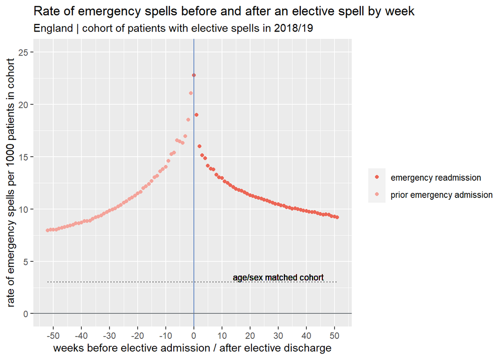

```r
IneqSecCareReadm_Weekly %>%
  filter(elapsedWeeks >= -52, elapsedWeeks <= 51) %>%
  filter(!is.na(priorPostLabel)) %>%
  filter(indexImdQ == 'all') %>%
  filter(indexSTP == 'all') %>%
  filter(indexIcd10Chapter == 'all') %>%
  ggplot() +
  geom_point(aes(x = elapsedWeeks, y = 1000*pProxAdm, colour = priorPostLabel)) +
  geom_line(aes(x = elapsedWeeks, y = 1000*pExpProxAdm_ASOnly), linetype = 'dotted') +
  geom_text(aes(x = 30, y = 1000*(pExpProxAdm_ASOnly + 0.0005), label = 'age/sex matched cohort'), size = 3) +
  geom_vline(aes(xintercept = 0), colour = '#5881c1') +
  geom_hline(aes(yintercept = 0), colour = '#686f73') +
  scale_x_continuous(name = 'weeks before elective admission / after elective discharge',
                     limits = c(-52, 51),
                     breaks = seq(-50, 50, 10)) +
  scale_y_continuous(name = 'rate of emergency spells per 1000 patients in cohort',
                     limits = c(0, 1000*0.025)) +  #,
                     #labels = percent_format(accuracy = 0.1)) +
  scale_colour_manual(labels = c('emergency readmission', 'prior emergency admission', ''),
                      values = c('#ec6555', '#f4a39a')) +
  labs(title = 'Rate of emergency spells before and after an elective spell by week',
       subtitle = 'England | cohort of patients with elective spells in 2018/19') +
  theme(legend.title = element_blank())
```

```r
proxAdmEstimates <- IneqSecCareReadm_Weekly %>%
  filter(elapsedWeeks >= -52, elapsedWeeks <= 51) %>%
  filter(!is.na(priorPostLabel)) %>%
  filter(indexImdQ == 'all') %>%
  filter(indexSTP == 'all') %>%
  filter(indexIcd10Chapter == 'all') %>%
  group_by(priorPostLabel) %>%
  summarise(pProxAdm = sum(pProxAdm)) %>%
  mutate(period = '1 year') %>%
  bind_rows(IneqSecCareReadm_Weekly %>%
    filter(elapsedWeeks >= -6, elapsedWeeks <= 5) %>%
    filter(!is.na(priorPostLabel)) %>%
    filter(indexImdQ == 'all') %>%
    filter(indexSTP == 'all') %>%
    filter(indexIcd10Chapter == 'all') %>%
    group_by(priorPostLabel) %>%
    summarise(pProxAdm = sum(pProxAdm)) %>%
    mutate(period = '6 weeks')) %>%
  bind_rows(IneqSecCareReadm_Weekly %>%
    filter(elapsedWeeks >= -1, elapsedWeeks <= 0) %>%
    filter(!is.na(priorPostLabel)) %>%
    filter(indexImdQ == 'all') %>%
    filter(indexSTP == 'all') %>%
    filter(indexIcd10Chapter == 'all') %>%
    group_by(priorPostLabel) %>%
    summarise(pProxAdm = sum(pProxAdm)) %>%
    mutate(period = '1 week')) %>%
  select(priorPostLabel, period, pProxAdm) %>%
  mutate(ProxAdm1000 = 1000 * pProxAdm)
```

Rates of emergency spells increase in the weeks and months leading up to an elective admission. For every 1,000 elective spells, there are 21 emergency spells in the week before admission, 106 in the six weeks before admission and 587 in the year before admission.

Rates of emergency admissions reduce in a similar fashion after an elective spell. For every 1,000 elective spells, there are 23 emergency spells in the week after discharge, 102 in the six weeks after discharge and 602 in the year after discharge.

Rates of emergency admissions in the year before and after an elective spell are consistently higher than in an age and sex matched cohort who do not experience an elective admission.

###### 3.3.3 Prior and post emergency spells by deprivation

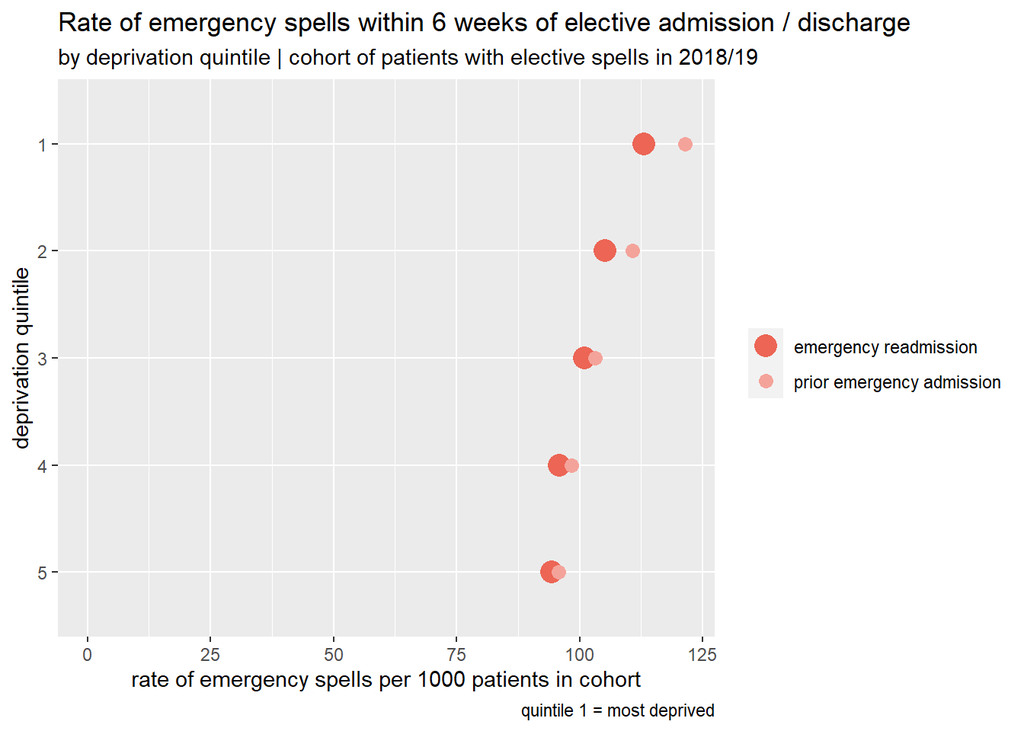

```r
IneqSecCareReadm_Weekly %>%
  filter(elapsedWeeks >= -6, elapsedWeeks <= 5) %>%
  filter(!is.na(priorPostLabel)) %>%
  filter(indexImdQ != 'all') %>%
  filter(indexIcd10Chapter == 'all') %>%
  filter(indexSTP  == 'all') %>%
  group_by(priorPostLabel, indexImdQ) %>%
  summarise(pProxAdm = sum(pProxAdm)) %>%
  mutate(indexImdQ = factor(indexImdQ)) %>%
  ggplot() +
  geom_point(aes(x = 1000*pProxAdm, y = reorder(indexImdQ, desc(indexImdQ)),
                 colour = priorPostLabel,
                 size = priorPostLabel)) +
  scale_y_discrete(name = 'deprivation quintile') +
  scale_x_continuous(name = 'rate of emergency spells per 1000 patients in cohort',
                     limits = c(0, NA_real_),) +
  scale_colour_manual(values = c('#ec6555', '#f4a39a')) +
  scale_size_manual(values = c(5, 3)) +
  labs(title = 'Rate of emergency spells within 6 weeks of elective admission / discharge',
       subtitle = 'by deprivation quintile | cohort of patients with elective spells in 2018/19',
        caption = 'quintile 1 = most deprived') +
  theme(legend.title = element_blank())
```

Rates of emergency spells are higher in the six weeks before and after an elective spell for those patients living in the most deprived areas.

Rates of emergency spells are marginally higher in the six weeks before an elective spell than in the six weeks post discharge, and the differential is greatest for patients living in the most deprived areas.

### 4 Modelling the impact of elective activity on emergency activity

The data presented in the previous sections is consistent with a causal link between the elective and emergency spells. We now attempt to formally test this causal link use panel regression methods.

- Outcome variable: emergency spells
- Panel variables: time (quarters), and CCG of residence
- Independent variables: elective spells (plus 8 lags), outpatient attendances (plus 4 lags), deaths, age/sex population profile, year and quarter.
- Exposure variable: population

Pooled, fixed effects and random effects models are developed and compared.

##### 4.1 Wrange data

Create panel dataset. For annual variables, interpolate quarterly values using loess models. Add lagged variables (8 quarters for elective spells and 4 quarters for outpatient attendnaces) and first 10 data points where lagged values take NA values.

```r
IneqSecCarePanel_wkg <- IneqSecCarePanel %>%
  mutate(yrId = Yr - 2001,
         qtrId = as.factor(calQtr),
         ccgId = factor(CCG20CD)) %>%
  mutate(perId = 4*(yrId + as.numeric(calQtr - 1)*0.25) - 3) %>%
  mutate(popSmooth = NA_real_,
         popFSmooth  = NA_real_,
         pop65plusSmooth  = NA_real_,
         pop75plusSmooth  = NA_real_,
         pop85plusSmooth  = NA_real_,
         pop19lessSmooth  = NA_real_,
         deathsSmooth  = NA_real_)

# interpolate into quarters the terms at are annual only ----

# create data frame to create smoothing (interpolation) models

IneqSecCarePanel_SmoothModDf <- IneqSecCarePanel_wkg %>%
  group_by(CCG20CD, yrId, calQtr) %>%
  summarise(pop = sum(pop),
            popF = sum(popF),
            pop65plus = sum(pop65plus),
            pop75plus = sum(pop75plus),
            pop85plus = sum(pop85plus),
            pop19less = sum(pop19less),
            deaths = sum(deaths)) %>%
  group_by(CCG20CD, yrId) %>%
  summarise(pop = sum(pop)/n(),
            popF = sum(popF)/n(),
            pop65plus = sum(pop65plus)/n(),
            pop75plus = sum(pop75plus)/n(),
            pop85plus = sum(pop85plus)/n(),
            pop19less = sum(pop19less)/n(),
            deaths = if_else(yrId == 1, mean(0.75*deaths)/n(), mean(deaths)/n()))  %>%
  mutate(perId = 4*(yrId - 1) + 2.5)


# create list of CCGs

CCG20CDList <- IneqSecCarePanel_SmoothModDf %>%
  distinct(CCG20CD)


# for each CCG, create models to smooth annual terms and update wkg df with smoothed values

for (i in CCG20CDList$CCG20CD)
{


  modDf <- IneqSecCarePanel_SmoothModDf %>%
    filter(CCG20CD == i)

  modPop <- loess(pop ~ perId,
                  span = .4,
                  data = modDf,
                  control = loess.control(surface = 'direct'))

  modPopF <- loess(popF ~ perId,
                   span = .4,
                   data = modDf,
                   control = loess.control(surface = 'direct'))

  modPop65plus <- loess(pop65plus ~ perId,
                        span = .4,
                        data = modDf,
                        control = loess.control(surface = 'direct'))

  modPop75plus <- loess(pop75plus ~ perId,
                        span = .4,
                        data = modDf,
                        control = loess.control(surface = 'direct'))

  modPop85plus <- loess(pop85plus ~ perId,
                        span = .4,
                        data = modDf,
                        control = loess.control(surface = 'direct'))

  modPop19less <- loess(pop19less ~ perId,
                        span = .4,
                        data = modDf,
                        control = loess.control(surface = 'direct'))

  modDeaths <- loess(deaths ~ perId,
                     span = .4,
                     data = modDf,
                     control = loess.control(surface = 'direct'))

  IneqSecCarePanel_wkg <- IneqSecCarePanel_wkg %>%
    mutate(popSmooth = if_else(CCG20CD == i,
                               predict(modPop, newdata = IneqSecCarePanel_wkg),
                               popSmooth),
           popFSmooth = if_else(CCG20CD == i,
                                predict(modPopF, newdata = IneqSecCarePanel_wkg),
                                popFSmooth),
           pop65plusSmooth = if_else(CCG20CD == i,
                                     predict(modPop65plus, newdata = IneqSecCarePanel_wkg),
                                     pop65plusSmooth),
           pop75plusSmooth = if_else(CCG20CD == i,
                                     predict(modPop75plus, newdata = IneqSecCarePanel_wkg),
                                     pop75plusSmooth),
           pop85plusSmooth = if_else(CCG20CD == i,
                                     predict(modPop85plus, newdata = IneqSecCarePanel_wkg),
                                     pop85plusSmooth),
           pop19lessSmooth = if_else(CCG20CD == i,
                                     predict(modPop19less, newdata = IneqSecCarePanel_wkg),
                                     pop19lessSmooth),
           deathsSmooth = if_else(CCG20CD == i,
                                  predict(modDeaths, newdata = IneqSecCarePanel_wkg),
                                  deathsSmooth))

}


rm(IneqSecCarePanel_SmoothModDf)
rm(modDf, modDeaths, modPop, modPop19less,
   modPop65plus, modPop75plus, modPop85plus,
   modPopF)


# update  rates based on smoothed terms
IneqSecCarePanel_wkg <- IneqSecCarePanel_wkg %>%
  mutate(ipElec = ipElecDC + ipElecOrd) %>%
  mutate(ipEmerRate = ipEmer / popSmooth,
         ipElecRate = ipElec / popSmooth,
         opAllRate = opAll / popSmooth) %>%
  mutate(deathRate = deathsSmooth / popSmooth) %>%
  mutate(pPop65plus = pop65plusSmooth / popSmooth,
         pPop75plus = pop75plusSmooth / popSmooth,
         pPop85plus = pop85plusSmooth / popSmooth,
         pPop19less = pop19lessSmooth / popSmooth,
         pPopF = popFSmooth / popSmooth) %>%
  mutate(ccgIdN = as.numeric(ccgId)) %>%
  arrange(ccgId, perId)


# create df for the models
# add 8 quarter lags for ipElec and 4 quarter lags for opAll
# strip out first 10 periods so that all rows have full set of data

IneqSecCarePanel_ModWkg <- IneqSecCarePanel_wkg %>%
  mutate(ipElecRateL1 = dplyr::lag(ipElecRate, n = 1),
         ipElecRateL2 = dplyr::lag(ipElecRate, n = 2),
         ipElecRateL3 = dplyr::lag(ipElecRate, n = 3),
         ipElecRateL4 = dplyr::lag(ipElecRate, n = 4),
         ipElecRateL5 = dplyr::lag(ipElecRate, n = 5),
         ipElecRateL6 = dplyr::lag(ipElecRate, n = 6),
         ipElecRateL7 = dplyr::lag(ipElecRate, n = 7),
         ipElecRateL8 = dplyr::lag(ipElecRate, n = 8),
         opAllRateL1 = dplyr::lag(opAllRate, n = 1),
         opAllRateL2 = dplyr::lag(opAllRate, n = 2),
         opAllRateL3 = dplyr::lag(opAllRate, n = 3),
         opAllRateL4 = dplyr::lag(opAllRate, n = 4)) %>%
  filter(perId >= 10)
```

##### 4.2 Create models

```r
mod_formula <- as.formula('ipEmerRate ~ yrId + qtrId +
                              avIMD2019 +
                              deathRate +
                              pPop65plus + pPop75plus + pPop85plus + pPop19less + pPopF +
                              ipElecRate +
                              ipElecRateL1 + ipElecRateL2 + ipElecRateL3 + ipElecRateL4 +
                              ipElecRateL5 + ipElecRateL6 + ipElecRateL7 + ipElecRateL8 +
                              opAllRate +
                              opAllRateL1 + opAllRateL2 + opAllRateL3 + opAllRateL4')

# create three models - pooled effects, fixed effects, random effects

prelimModel_Pooled <- plm(mod_formula,
                          data = IneqSecCarePanel_ModWkg,
                          model = "pooling",
                          index = c("ccgIdN", "perId"))


prelimModel_Fixed <- plm(mod_formula,
                         data = IneqSecCarePanel_ModWkg,
                         model = "within",
                         index = c("ccgIdN", "perId"))


prelimModel_Random <- plm(mod_formula,
                          data = IneqSecCarePanel_ModWkg,
                          model = "random",
                          index = c("ccgIdN", "perId"))


plmtest(prelimModel_Pooled) # random superior to pooled
```

```
##
##  Lagrange Multiplier Test - (Honda) for balanced panels
##
## data:  mod_formula
## normal = 233.98, p-value < 2.2e-16
## alternative hypothesis: significant effects
```

```r
pFtest(prelimModel_Fixed, prelimModel_Pooled) # fixed superior to pooled
```

[output not shown]

```r
phtest(prelimModel_Random, prelimModel_Fixed) # fixed superior to random
```

```
##
##  Hausman Test
##
## data:  mod_formula
## chisq = 68.82, df = 24, p-value = 3.295e-06
## alternative hypothesis: one model is inconsistent
```

```r
finalModel <- plm(ipEmerRate ~ yrId + qtrId +
                    deathRate +
                    pPop65plus + pPop75plus + pPop85plus + pPop19less + pPopF +
                    ipElecRate +
                    ipElecRateL1 + ipElecRateL2 + ipElecRateL3 + ipElecRateL4 +
                    ipElecRateL5 + ipElecRateL6 + ipElecRateL7 + ipElecRateL8 +
                    opAllRate +
                    opAllRateL1 + opAllRateL2 + opAllRateL3 + opAllRateL4,
                         data = IneqSecCarePanel_ModWkg,
                         model = "within",
                         index = c("ccgIdN", "perId"))
# note that avIMD2019 term is dropped in fixed effect model = because it is perfectly colinear with the CCG fixed effect term
# so dropping this term from the formula for neatness

modelCovariatesCoefficients <- tidy(finalModel) %>%
  rename(covariate = term) %>%
  mutate(coefficient = round(estimate, 4),
         p = round(`p.value`, 4),
         lcl95 = round(estimate - 1.96*std.error, 4),
         ucl95= round(estimate + 1.96*std.error, 4)) %>%
  select(covariate, coefficient,lcl95, ucl95, p)

modelCovariatesCoefficients %>%
  print(n = 24)
```

```
## # A tibble: 24 x 5
##    covariate    coefficient     lcl95     ucl95      p
##    <chr>              <dbl>     <dbl>     <dbl>  <dbl>
##  1 yrId            0.000300  0.0002    0.000300 0
##  2 qtrId2         -0.0008   -0.0009   -0.000600 0
##  3 qtrId3         -0.0011   -0.00120  -0.0009   0
##  4 qtrId4          0.0001    0         0.0002   0.196
##  5 deathRate       1.62      1.01      2.23     0
##  6 pPop65plus     -0.0042   -0.0163    0.0079   0.499
##  7 pPop75plus      0.0269   -0.0055    0.0593   0.104
##  8 pPop85plus      0.231     0.169     0.294    0
##  9 pPop19less      0.0431    0.0327    0.0535   0
## 10 pPopF           0.126     0.095     0.156    0
## 11 ipElecRate      0.204     0.176     0.232    0
## 12 ipElecRateL1   -0.0543   -0.0882   -0.0203   0.0017
## 13 ipElecRateL2   -0.0216   -0.0558    0.0126   0.215
## 14 ipElecRateL3   -0.0296   -0.0638    0.0047   0.0906
## 15 ipElecRateL4   -0.0019   -0.0357    0.0319   0.910
## 16 ipElecRateL5   -0.014    -0.0463    0.0184   0.396
## 17 ipElecRateL6   -0.0042   -0.0365    0.0281   0.799
## 18 ipElecRateL7   -0.0013   -0.0334    0.0308   0.936
## 19 ipElecRateL8    0.0204   -0.0068    0.0476   0.142
## 20 opAllRate       0.0021   -0.0001    0.0043   0.0562
## 21 opAllRateL1    -0.0028   -0.0055   -0.0001   0.0437
## 22 opAllRateL2     0.0007   -0.002     0.0034   0.604
## 23 opAllRateL3    -0.0001   -0.0028    0.0026   0.954
## 24 opAllRateL4     0.0015   -0.000600  0.0036   0.165
```

The Lagrange Multiplier test, F test and Hausman test suggests that the fixed effects model is superior to the pooled and random effects models.

The relationship between the number of emergency and elective spells is complex. The number of emergency admissions is higher in a quarter when the number of elective admissions is higher, but this should not be seen as evidence that elective spells serve to increase emergency spells. Many of the emergency admissions in fact predate the elective spell, indicating potential reverse causality. Moreover, rates of elective spells may be controlling for other unobserved drivers of the rate of emergency admissions.

However, the lagged effects of elective spells on emergency spells are somewhat easier to interpret. Because, by definition, these spells predate the emergency spells, any possible causal impact can only operate in one direction (elective spells >> emergency spells). The coefficients for the lagged elective spell variables are largely negative, suggesting the increasing the rate of elective spells applies a lagged, downward pressure on the rate of emergency spells. The scale of this effect is strongest in the first quarter after the increase any elective spells and is dissipates slowly. By the eighth quarter after an increase in the rate of elective spells, the impact on the rate of emergency spells is negligible.

The relationship between the number of emergency and outpatient attendances follows a similar patterns, but the strength of the association is substantially weaker and the lagged effect is more short-lived.

##### 4.3 Estimate cumulative lagged effects

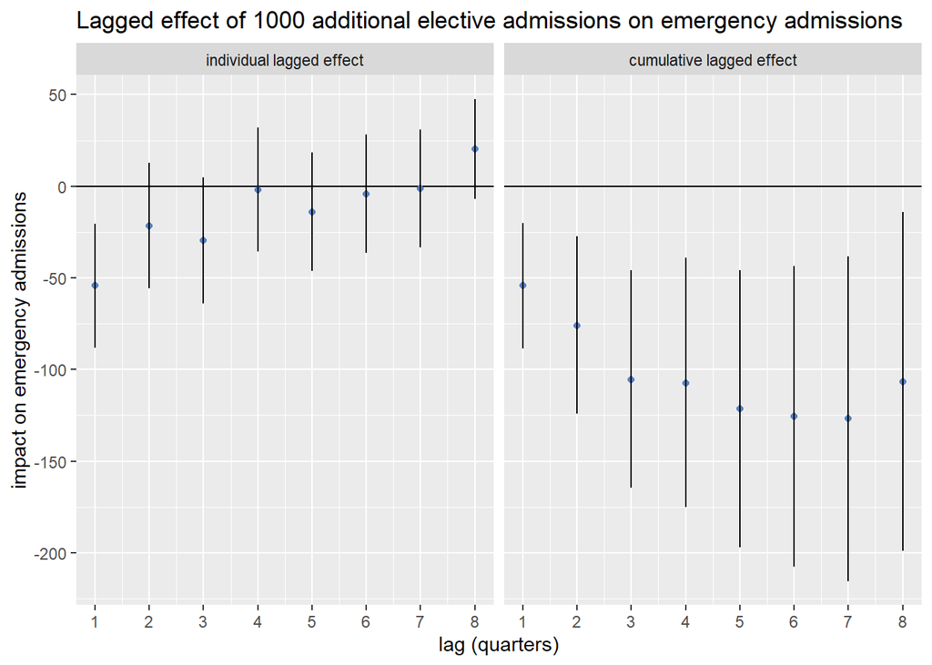

```r
# bootstrap to get CIs, 10,000 reps

ipElecLagsCuml <- tidy(finalModel)[12:19, ] %>%
  mutate(estRandN = NA_real_,
         lcl95 = estimate - 1.96*std.error,
         ucl95 = estimate + 1.96*std.error) %>%
  mutate(lag = as.numeric(substr(term, nchar(term), nchar(term))),
         indCuml = 'individual lagged effect',
         pod = 'inpatient elective')

nSamp <- 100000

bsIpElecLagsCuml <- ipElecLagsCuml[rep(seq_len(nrow(ipElecLagsCuml)), times = nSamp), ] %>%
    mutate(bsN = rep(seq_len(nSamp), each = nrow(ipElecLagsCuml))) %>%
    mutate(randN = rnorm(nSamp * nrow(ipElecLagsCuml))) %>%
    mutate(estRandN = estimate + randN*std.error)



for (k in (1:8))

  {
    cumlEffect <- bsIpElecLagsCuml %>%
    filter(lag <= k) %>%
    group_by(bsN) %>%
    summarise(estimate = sum(estimate),
              estRandN = sum(estRandN)) %>%
    ungroup() %>%
    mutate(estRandNLessZero = ifelse(estRandN < 0 , 1, 0))

  ipElecLagsCuml <- ipElecLagsCuml %>%
    bind_rows(data.frame(estimate = mean(cumlEffect$estimate),
                         estRandN = mean(cumlEffect$estRandN),
                         lcl95 = quantile(cumlEffect$estRandN, 0.025),
                         ucl95 = quantile(cumlEffect$estRandN, 0.975),
                         p.value = 1 - (sum(cumlEffect$estRandNLessZero) / nSamp),
                         term = paste('ipElecRateL', k, 'Cuml', sep = ''),
                         std.error = NA_real_,
                         statistic = NA_real_,
                         lag = k,
                         indCuml = 'cumulative lagged effect',
                         pod = 'inpatient elective'))

  }



opAllLagsCuml <- tidy(finalModel)[21:24, ] %>%
  mutate(estRandN = NA_real_,
         lcl95 = estimate - 1.96*std.error,
         ucl95 = estimate + 1.96*std.error) %>%
  mutate(lag = as.numeric(substr(term, nchar(term), nchar(term))),
         indCuml = 'individual lagged effect',
         pod = 'outpatient')

bsOpAllLagsCuml <- opAllLagsCuml[rep(seq_len(nrow(opAllLagsCuml)), times = nSamp), ] %>%
  mutate(bsN = rep(seq_len(nSamp), each = nrow(opAllLagsCuml))) %>%
  mutate(randN = rnorm(nSamp * nrow(opAllLagsCuml))) %>%
  mutate(estRandN = estimate + randN*std.error) %>%
  mutate(lag = as.numeric(substr(term, nchar(term), nchar(term)))) %>%
  ungroup()



for (k in (1:4))

{
  cumlEffect <- bsOpAllLagsCuml %>%
    filter(lag <= k) %>%
    group_by(bsN) %>%
    summarise(estimate = sum(estimate),
              estRandN = sum(estRandN)) %>%
    ungroup() %>%
    mutate(estRandNLessZero = ifelse(estRandN < 0 , 1, 0))


  opAllLagsCuml <- opAllLagsCuml %>%
    bind_rows(data.frame(estimate = mean(cumlEffect$estimate),
                         estRandN = mean(cumlEffect$estRandN),
                         lcl95 = quantile(cumlEffect$estRandN, 0.025),
                         ucl95 = quantile(cumlEffect$estRandN, 0.975),
                         p.value = 1 - (sum(cumlEffect$estRandNLessZero) / nSamp),
                         term = paste('ipElecRateL', k, 'Cuml', sep = ''),
                         std.error = NA_real_,
                         statistic = NA_real_,
                         lag = k,
                         indCuml = 'cumulative lagged effect',
                         pod = 'outpatient'))

}


laggedEffectsCuml <- ipElecLagsCuml %>%
  bind_rows(opAllLagsCuml) %>%
  mutate(indCuml = factor(indCuml, levels = c('individual lagged effect', 'cumulative lagged effect')))


# plot individual lagged and cumulative lagged effect from coefficients

laggedEffectsCuml %>%
  filter(pod == 'inpatient elective') %>%
  ggplot() +
  geom_hline(aes(yintercept = 0)) +
  geom_point(aes(x = lag, y = estimate*1000), colour =  '#5881c1') +
  geom_segment(aes(x = lag, xend = lag, y = lcl95*1000, yend = ucl95*1000)) +
  scale_y_continuous(name = 'impact on emergency admissions') +
  scale_x_continuous(name = 'lag (quarters)', breaks = seq(1, 8, 1)) +
  facet_grid(cols = vars(indCuml)) +
  labs(title = 'Lagged effect of 1000 additional elective admissions on emergency admissions') +
  theme(legend.position = 'none')
```

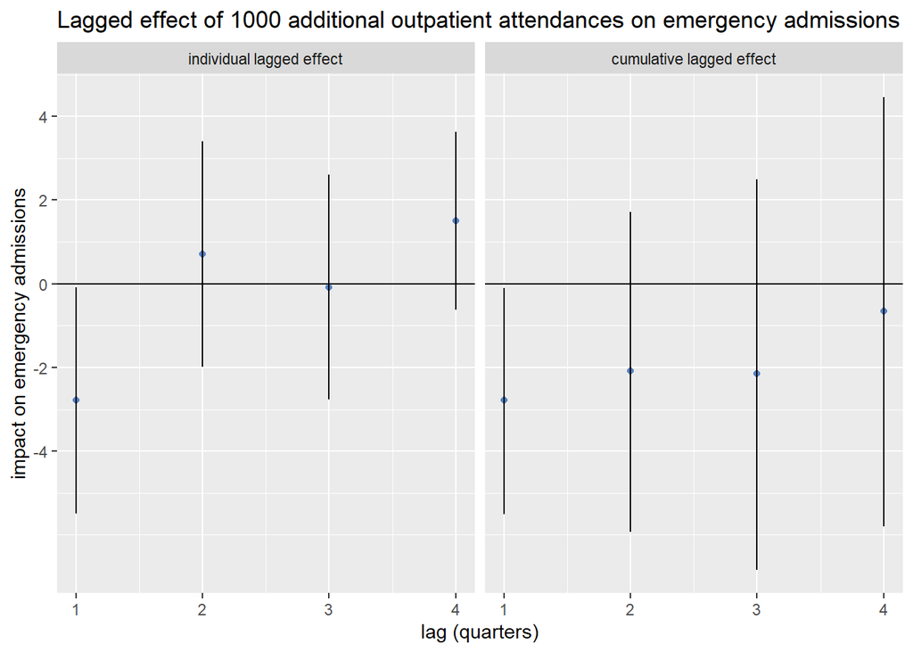

```r
laggedEffectsCuml %>%
  filter(pod == 'outpatient') %>%
  ggplot() +
  geom_hline(aes(yintercept = 0)) +
  geom_point(aes(x = lag, y = estimate*1000), colour =  '#5881c1') +
  geom_segment(aes(x = lag, xend = lag, y = lcl95*1000, yend = ucl95*1000)) +
  scale_y_continuous(name = 'impact on emergency admissions', breaks = c(-4, -2, 0, 2, 4, 6)) +
  scale_x_continuous(name = 'lag (quarters)', breaks = seq(1, 4, 1)) +
  facet_grid(cols = vars(indCuml)) +
  labs(title = 'Lagged effect of 1000 additional outpatient attendances on emergency admissions') +
  theme(legend.position = 'none')
```

The charts above show the individual and cumulative lagged effect on the number of emergency admissions of increasing the number of elective spells and outpatient attendances.

The model suggests that increasing the number of elective spells by 1000 per quarter would lead to a decrease of 107 within 2 years (95% CI 14 to 199 emergency spells).

##### 4.4 Predict emergency spells if the crude rate of elective spell rates in each deprivation quintile were equalised upwards, in each STP

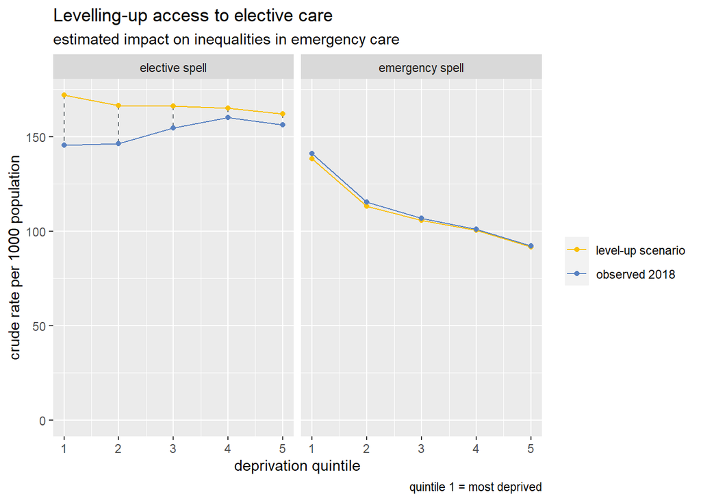

```r
## predict ipEmer with model for later comparison
IneqSecCarePanel_ModWkg <- IneqSecCarePanel_ModWkg %>%
  mutate(predFE_ipEmerRate_demean = predict(finalModel)) %>%
  left_join(IneqSecCarePanel_ModWkg %>%
              group_by(ccgIdN) %>%
              summarise(ipEmerRateMean = mean(ipEmerRate)),
            by = 'ccgIdN')

modCoefsMatrix <- tidy(finalModel) %>%
  dplyr::select(estimate) %>%
  as.matrix()

IneqSecCarePanel_ModWkg <- IneqSecCarePanel_ModWkg %>%
  mutate(predFE_ipEmerRate = model.matrix(finalModel) %*% modCoefsMatrix + ipEmerRateMean)


# identify the value of ipElec  in the IMD quintile with the highest rate in each STP
maxIpElecStpYr <- actRates %>%
  filter(actType == c('ipElec')) %>%
  filter(rateType == 'crude') %>%
  filter(imd2019Dec != 'all') %>%
  filter(icd10Chapter == 'all') %>%
  filter(STP20CD != 'all') %>%
  mutate(imdQ = case_when(imd2019Dec %in% c(1, 2) ~ 1,
                          imd2019Dec %in% c(3, 4) ~ 2,
                          imd2019Dec %in% c(5, 6) ~ 3,
                          imd2019Dec %in% c(7, 8) ~ 4,
                          imd2019Dec %in% c(9, 10) ~ 5)) %>%
  group_by(yr, STP20CD, STP20Nm, STP20ShNm, imdQ) %>%
  summarise(rate = sum(rate * pop) / sum (pop),
            pop = sum(pop)) %>%
  group_by(yr, STP20CD, STP20Nm, STP20ShNm) %>%
  summarise(maxRate = max(rate))


###calculate additional ipElec activity to level-up rates in each STP
levelUpYrImdQStp <- actRates %>%
  filter(actType == c('ipElec')) %>%
  filter(rateType == 'crude') %>%
  filter(imd2019Dec != 'all') %>%
  filter(icd10Chapter == 'all') %>%
  filter(STP20CD != 'all') %>%
  mutate(imdQ = case_when(imd2019Dec %in% c(1, 2) ~ 1,
                          imd2019Dec %in% c(3, 4) ~ 2,
                          imd2019Dec %in% c(5, 6) ~ 3,
                          imd2019Dec %in% c(7, 8) ~ 4,
                          imd2019Dec %in% c(9, 10) ~ 5)) %>%
  group_by(yr, STP20CD, STP20Nm, STP20ShNm, actType, imdQ) %>%
  summarise(rate = sum(rate * pop) / sum (pop),
            pop = sum(pop)) %>%
  left_join(maxIpElecStpYr,
            by = c('yr', 'STP20CD', 'STP20Nm', 'STP20ShNm')) %>%
  mutate(gapRate = maxRate - rate,
         gap = (maxRate - rate)*pop)

ipElecGapTotal <- levelUpYrImdQStp %>%
  filter(yr == 2018) %>%
  mutate(activity = rate * pop) %>%
  ungroup() %>%
  summarise(gap = sum(gap),
            baseActivity = sum(activity)) %>%
  mutate(pGap = gap / baseActivity)


levelUpYrStp <- levelUpYrImdQStp %>%
  group_by(yr, STP20CD) %>%
  summarise(gap = sum(gap))


### add these to IneqSecCarePanel_wkg
### note need to split to quarters (evenly) and from STP to CCG
popYrQtrStp <- IneqSecCarePanel_wkg %>%
  left_join(ccgStp, by = 'CCG20CD') %>%
  group_by(Yr, calQtr, STP20CD) %>%
  summarise(stpPop = sum(popSmooth))

IneqSecCarePanel_wkg_levelUp <- IneqSecCarePanel_wkg %>%
  left_join(ccgStp, by = 'CCG20CD') %>%
  left_join(popYrQtrStp, by = c('Yr', 'calQtr', 'STP20CD')) %>%
  left_join(levelUpYrStp %>%
              mutate(gapQtr = gap / 4) %>%
              dplyr::select(STP20CD, yr, adjNumStpIpElec = gapQtr),
            by = c('STP20CD', 'Yr' = 'yr')) %>%
  mutate(adjNumStpIpElec = ifelse(is.na(adjNumStpIpElec), 0, adjNumStpIpElec)) %>%
  mutate(adjNumCcgIpElec = adjNumStpIpElec * popSmooth / stpPop) %>%
  mutate(ipElec = ipElec + adjNumCcgIpElec) %>%
  mutate(ipElecRate = ipElec / popSmooth) %>%
  dplyr::select(-STP20CD, -stpPop, -adjNumStpIpElec, -adjNumCcgIpElec)


### add lags and filter earlier point with no data
IneqSecCarePanel_ModWkg_levelUp <- IneqSecCarePanel_wkg_levelUp %>%
  mutate(ipElecRateL1 = dplyr::lag(ipElecRate, n = 1),
         ipElecRateL2 = dplyr::lag(ipElecRate, n = 2),
         ipElecRateL3 = dplyr::lag(ipElecRate, n = 3),
         ipElecRateL4 = dplyr::lag(ipElecRate, n = 4),
         ipElecRateL5 = dplyr::lag(ipElecRate, n = 5),
         ipElecRateL6 = dplyr::lag(ipElecRate, n = 6),
         ipElecRateL7 = dplyr::lag(ipElecRate, n = 7),
         ipElecRateL8 = dplyr::lag(ipElecRate, n = 8),
         opAllRateL1 = dplyr::lag(opAllRate, n = 1),
         opAllRateL2 = dplyr::lag(opAllRate, n = 2),
         opAllRateL3 = dplyr::lag(opAllRate, n = 3),
         opAllRateL4 = dplyr::lag(opAllRate, n = 4)) %>%
  filter(perId >= 10)


### produce model matrix in required (CCG centred) format
modMatrix_levelUp <- model.matrix(ipEmerRate ~ yrId + qtrId +
                                    deathRate +
                                    pPop65plus + pPop75plus + pPop85plus + pPop19less + pPopF +
                                    ipElecRate +
                                    ipElecRateL1 + ipElecRateL2 + ipElecRateL3 + ipElecRateL4 +
                                    ipElecRateL5 + ipElecRateL6 + ipElecRateL7 + ipElecRateL8 +
                                    opAllRate +
                                    opAllRateL1 + opAllRateL2 + opAllRateL3 + opAllRateL4,
                                  data = IneqSecCarePanel_ModWkg_levelUp)[,-1]


### adjust it by calculating centering adjustments in original model
basicMatrix <- model.matrix(ipEmerRate ~ yrId + qtrId +
                              deathRate +
                              pPop65plus + pPop75plus + pPop85plus + pPop19less + pPopF +
                              ipElecRate +
                              ipElecRateL1 + ipElecRateL2 + ipElecRateL3 + ipElecRateL4 +
                              ipElecRateL5 + ipElecRateL6 + ipElecRateL7 + ipElecRateL8 +
                              opAllRate +
                              opAllRateL1 + opAllRateL2 + opAllRateL3 + opAllRateL4,
                            data = IneqSecCarePanel_ModWkg)[,-1]

ccgCentredMatrix <- model.matrix(finalModel)

adjMatrix <- basicMatrix - ccgCentredMatrix

modMatrixCcgCentred_levelUp <- modMatrix_levelUp - adjMatrix


# substitute new ipElecRate with previous rates (because I don't want to adjust for concurrent changes)
modMatrixCcgCentred_levelUp[,11] <- model.matrix(finalModel)[,11]


### estimate impact of the leveling up of elective care
levelUpImpactStp <- IneqSecCarePanel_ModWkg %>%
  bind_cols(IneqSecCarePanel_ModWkg_levelUp %>%
              dplyr::select(ipElecRate_levelUp = ipElecRate,
                            ipElecRateL1_levelUp = ipElecRateL1,
                            ipElecRateL2_levelUp = ipElecRateL2,
                            ipElecRateL3_levelUp = ipElecRateL3,
                            ipElecRateL4_levelUp = ipElecRateL4,
                            ipElecRateL5_levelUp = ipElecRateL5,
                            ipElecRateL6_levelUp = ipElecRateL6,
                            ipElecRateL7_levelUp = ipElecRateL7,
                            ipElecRateL8_levelUp = ipElecRateL8,
                            ipEmerRate_levelUp = ipEmerRate)) %>%
  mutate(predFE_ipEmerRate_levelUp = modMatrixCcgCentred_levelUp %*% modCoefsMatrix + ipEmerRateMean) %>%
  mutate(ipEmerRateDiff = predFE_ipEmerRate_levelUp - predFE_ipEmerRate,
         ipElecRateDiff = ipElecRate_levelUp - ipElecRate) %>%
  mutate(ipEmerDiff = ipEmerRateDiff * pop,
         ipElecDiff = ipElecRateDiff * pop) %>%
  left_join(ccgStp, by = 'CCG20CD') %>%
  filter(Yr == 2018) %>%
  filter(STP20CD != 'all') %>%
  group_by(STP20CD) %>%
  summarise(ipEmerDiff = sum(ipEmerDiff),
            ipElecDiff = sum(ipElecDiff))


# split out impact by IMDQ
levelUpImpactImdQStp <- levelUpImpactStp %>%
  left_join(levelUpYrImdQStp %>%
            ungroup() %>%
            filter(yr == 2018) %>%
            select(STP20CD, imdQ, gap) %>%
            filter(STP20CD != 'all') %>%
            group_by(STP20CD) %>%
            mutate(levelUpShare = gap / sum(gap)) %>%
            select(STP20CD, imdQ, levelUpShare),
            by = 'STP20CD') %>%
  mutate(ipElecDiff = ipElecDiff * levelUpShare,
         ipEmerDiff = ipEmerDiff * levelUpShare) %>%
  select(-levelUpShare)




## calculate ipEmer rates at baseline  in 2018 (i.e. before leveling up)
ipEmerDiffRatesBaseline <- actRates %>%
  filter(actType %in% c('ipEmer')) %>%
  filter(rateType == 'crude') %>%
  filter(imd2019Dec != 'all') %>%
  filter(icd10Chapter == 'all') %>%
  filter(STP20CD != 'all') %>%
  mutate(imdQ = case_when(imd2019Dec %in% c(1, 2) ~ 1,
                          imd2019Dec %in% c(3, 4) ~ 2,
                          imd2019Dec %in% c(5, 6) ~ 3,
                          imd2019Dec %in% c(7, 8) ~ 4,
                          imd2019Dec %in% c(9, 10) ~ 5)) %>%
  filter(yr == 2018) %>%
  filter(STP20CD != 'all') %>%
  group_by(yr, STP20CD, STP20Nm, STP20ShNm, actType, imdQ) %>%
  summarise(rate = sum(rate * pop) / sum (pop),
            pop = sum(pop))


# impact on elective and emergency inequalities
actRates %>%
  filter(actType == 'ipElec' | actType == 'ipEmer') %>%
  filter(rateType == 'crude') %>%
  filter(STP20CD != 'all') %>%
  filter(yr == 2018) %>%
  filter(imd2019Dec != 'all') %>%
  filter(icd10Chapter == 'all') %>%
  mutate(imdQ = case_when(imd2019Dec %in% c(1, 2) ~ 1,
                          imd2019Dec %in% c(3, 4) ~ 2,
                          imd2019Dec %in% c(5, 6) ~ 3,
                          imd2019Dec %in% c(7, 8) ~ 4,
                          imd2019Dec %in% c(9, 10) ~ 5)) %>%
  mutate(varRate = ((rate - lcl95)/qnorm(0.975, mean = 0, sd = 1))^2) %>%
  group_by(yr, STP20CD, STP20Nm, STP20ShNm, midsStp, imdQ, actType, actTypeLabel, rateType) %>%
  summarise(rate = sum(rate * pop) / sum(pop),
            varRate = sum(varRate * pop) / sum(pop),
            pop = sum(pop)) %>%
  ungroup() %>%
  left_join(levelUpImpactImdQStp %>%
              mutate(yr = 2018) %>%
              select(yr, STP20CD, imdQ, ipEmer = ipEmerDiff, ipElec = ipElecDiff) %>%
              pivot_longer(cols = 4:5,
                           names_to = 'actType',
                           values_to = 'impact'),
            by = c('yr', 'STP20CD', 'imdQ', 'actType')) %>%
  mutate(impact = ifelse(is.na(impact), 0, impact)) %>%
  rename(baseRate = rate,
         baseVarRate = varRate) %>%
  mutate(baseNum = baseRate * pop) %>%
  mutate(newRate = baseRate + (impact / pop),
         newNum = baseNum + impact) %>%
  select(-baseVarRate, -impact, - baseRate, - newRate) %>%
  pivot_longer(cols = 11:12,
               names_to = 'baseNew',
               values_to = 'num') %>%
  mutate(baseNew = ifelse(baseNew == 'baseNum', 'observed 2018', 'level-up scenario')) %>%
  mutate(baseNew = factor(baseNew, levels = c('level-up scenario', 'observed 2018'))) %>%
  mutate(actTypeLabel = factor(actTypeLabel, levels = c('elective spell', 'emergency spell'))) %>%
  mutate(rate = num / pop) %>%
  group_by(yr, imdQ, actType, actTypeLabel, baseNew) %>%
  summarise(rate = sum(num) / sum(pop),
            rate1 = sum(rate * pop) / sum(pop)) %>%
  mutate(rateBefore = dplyr::lead(rate, n = 1)) %>%
  ggplot() +
  geom_line(aes(x = imdQ, y = 1000*rate, colour = baseNew)) +
  geom_segment(aes(x = imdQ, xend = imdQ, y = 1000*rate, yend = 1000*rateBefore),
               colour = '#686f73',
               linetype = 'dashed' ) +
  geom_point(aes(x = imdQ, y = 1000*rate, colour = baseNew)) +

  scale_y_continuous(name = 'crude rate per 1000 population',
                     limits = c(0, NA_real_)) +
  scale_x_continuous(name = 'deprivation quintile',
                     breaks = c(1,2, 3, 4, 5)) +
  scale_colour_manual(values = c('#f9bf07', '#5881c1')) +
  facet_grid(cols = vars(actTypeLabel)) +
  theme(legend.title = element_blank()) +
  labs(title = 'Levelling-up access to elective care',
        subtitle = 'estimated impact on inequalities in emergency care',
        caption = 'quintile 1 = most deprived')
```

```r
ipEmerImpactTotal <- ipEmerDiffRatesBaseline %>%
  group_by(STP20CD, STP20Nm, STP20ShNm) %>%
  summarise(ipEmerBaselineNum = sum(rate * pop)) %>%
  left_join(levelUpImpactStp %>%
              select(-ipElecDiff),
            by = c('STP20CD')) %>%
  mutate(ipEmerDiffPc = ipEmerDiff / ipEmerBaselineNum) %>%
  ungroup() %>%
  summarise(baseActivity = sum(ipEmerBaselineNum),
            impact = sum(ipEmerDiff)) %>%
  mutate(pImpact = impact / baseActivity)
```

The number of elective spells would need to increased by 9.2% in order to ensure that crude rate of elective spells in each deprivation quintile was as high as the rate in the quintile with the highest rate within each STP.

Our model suggests that in this scenario, the rate of emergency admissions would reduce by 1.3% and the level of inequality in emergency admission rates would also be reduced.

##### 4.5 Estimate impact at STP-level of levelling-up access to elective care on emergency spells and inequalties in emergency spells

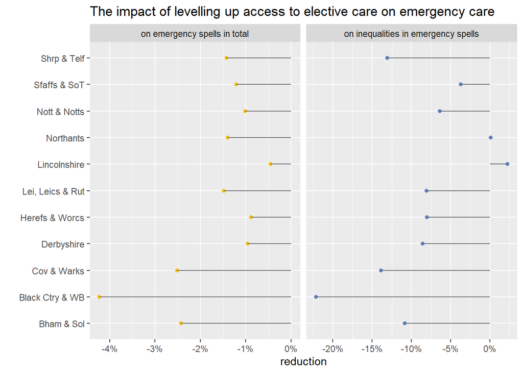

```r
### show levelling up as % of gap in ip Emer (by imdQ) and  % of all ipEmer
### estimate reduction in ipEmer overall by STP
ipEmerImpactStp <- ipEmerDiffRatesBaseline %>%
  group_by(STP20CD, STP20Nm, STP20ShNm) %>%
  summarise(ipEmerBaselineNum = sum(rate * pop)) %>%
  left_join(levelUpImpactStp %>%
              select(-ipElecDiff),
            by = c('STP20CD')) %>%
  mutate(ipEmerDiffPc = ipEmerDiff / ipEmerBaselineNum) %>%
  select(-ipEmerDiff, -ipEmerBaselineNum)


### estimate reduction in ipEmer inequalities by STP
ipEmerIneqImpactStp <- ipEmerDiffRatesBaseline %>%
  left_join(levelUpImpactImdQStp %>%
              select(-ipElecDiff),
            by = c('STP20CD', 'imdQ')) %>%
  filter(imdQ %in% c(1, 5)) %>%
  mutate(ipEmerRateLevelUp = ((rate * pop) + ipEmerDiff) / pop) %>%
  ungroup() %>%
  select(-yr, -actType, -pop, -ipEmerDiff) %>%
  pivot_longer(cols = 5:6,
               names_to = 'baseNew',
               values_to = 'rate') %>%
  pivot_wider(names_from = imdQ, values_from = rate, names_prefix = 'imdQ') %>%
  mutate(rateRatio = (imdQ1 / imdQ5) - 1) %>%
  select(-imdQ1, -imdQ5)  %>%
  pivot_wider(names_from = baseNew, values_from = rateRatio) %>%
  mutate(ipEmerIneqDiffPc = (ipEmerRateLevelUp / rate) - 1) %>%
  select(-rate, -ipEmerRateLevelUp)


ipEmerImpactStp %>%
  left_join(ipEmerIneqImpactStp,
            by = c('STP20CD', 'STP20Nm', 'STP20ShNm')) %>%
  pivot_longer(cols = 4:5,
               names_to = 'impactType',
               values_to = 'impact') %>%
  mutate(impactTypeLabel = ifelse(impactType == 'ipEmerDiffPc',
                                  'on emergency spells in total',
                                  'on inequalities in emergency spells')) %>%
  filter(STP20ShNm %in% c('Sfaffs & SoT', 'Shrp & Telf', 'Derbyshire', 'Lincolnshire',
                          'Nott & Notts', 'Lei, Leics & Rut', 'Black Ctry & WB', 'Bham & Sol',
                          'Cov & Warks', 'Herefs & Worcs', 'Northants')) %>%
  ggplot() +
  geom_point(aes(y = STP20ShNm, x = impact, colour = impactTypeLabel)) +
  geom_segment(aes(y = STP20ShNm, yend = STP20ShNm, x = 0, xend = impact),
               colour = '#686f73') +
  scale_y_discrete(name = '') +
  scale_x_continuous(name = 'reduction', labels = percent_format(accuracy = 1)) +
  scale_colour_manual(values = c('#f9bf07', '#5881c1')) +
  facet_wrap(~impactTypeLabel,
             scales = 'free_x',
             ncol = 2) +
  theme(legend.position = 'none') +
  labs(title = 'The impact of levelling up access to elective care on emergency care')
```

The scale of these effects varies by STP. In the Midlands, the Black Country & West Birmingham and Coventry & Warwickshire STPs would see the greatest benefits, with more modest effects seen in the Herefordshire & Worcestershire and Lincolnshire STPs.